# Конспект курса по R

```r
#Необходимые пакеты
library(readr)
library(tidyverse)
library(tidyr)
library(dplyr)
library(forcats)
library(flextable)
```

## Вселенная tidyverse

### Немного о данных

Основной набор данных – из файла data_tsv.tsv, который лежит в директории data. Сейчас я загружу его в переменную data. Создастся датафрейм, с которым я преимущественно и буду работать.

```r
data <- read_tsv("data/data_tsv.tsv", col_names = T, show_col_types = T) #Разделитель (tab) "вшит" по умолчанию в эту версию утилиты read_delim
    data$Группа <- factor(data$Группа)
    data$Пол <- factor(data$Пол)
    data$`Группа крови` <- factor(data$`Группа крови`, levels = c("A (II)", "B (III)", "O (I)", "AB (IV)"))
```

### Философия tidyverse

В одной картинке.

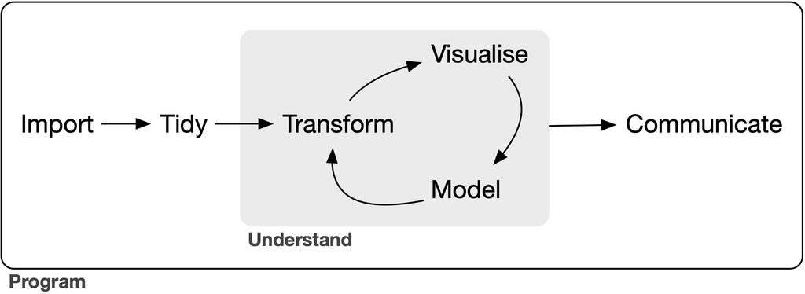

### Пайп |>

В редакторе Positron стандартный пайп можно вставить сочетанием Cmd+Shift+M (в Windows и Linux Ctrl+Shift+M).

### Импорт данных

Пакеты для чтения данных:

- readr (read_delim, read_tsv, read_csv, read_csv2),
- readxl (*.xlsx, *.xls),
- haven (SAS, SPSS).

Возвращают tibble – улучшенный датафрейм.

### Приведение в порядок и преобразование

1. `mutate()` — изменяет столбцы, добавляет новые;
2. `select()` — выбирает столбцы;
3. `filter()` — фильтрует строки по условиям;
4. `summarise()` — вычисляет сводные статистики;
5. `arrange()` — сортирует строки;
6. `group_by()` — группирует по значениям столбцов.

### Визуализация и коммуникация

- ggplot2 – красивые многослойные картинки,
- ggpubr – то же самое, но с готовыми функциями (расширяет функционал ggplot2),
- flextable – таблицы, которые нестыдно печатать в журналах и отчётах.

## Импорт данных

Общая функция – `read_delim()`, тип разделителя задаётся эксплицитно. В частных функциях `read_csv()`, `read_csv2()`, `read_tsv()` разделитель задаётся по умолчанию типом файла.

`write_delim()` – функция для записи данных из датафрейма в файл.

### Импорт из Excel и экспорт в Excel

Часто используемые пакеты: openxlsx, readxl.

```r
readxl::read_excel("data/data_excel.xlsx", sheet = "data") # Чтение из файла
openxlsx::write.xlsx(data, "out/data_excel.xlsx", colNames = TRUE) # Запись в файл
```

### R, SAS, SPSS

Rds – формат данных R. Функции `read_rds()` и `write_rds()`.

```r
read_rds("data/data_rds.rds")
write_rds(data, file="data/data_rds.rds")
```

### Добавление столбцов и строк

В tibble можно добавлять столбцы и строки следующими функциями:

- `add_column()`,
- `add_row()`.

`row_number()` – нумерация строк.

```r
data |>
  add_column(just_column = "just values", .before = 1) |>
  slice(1:3)
```

```
# A tibble: 3 × 14
  just_column Группа   Возраст Пол      Рост `Группа крови` Базофилы_E1
  <chr>       <fct>      <dbl> <fct>   <dbl> <fct>                <dbl>
1 just values Группа 1      31 Женский   174 A (II)               0.422
2 just values Группа 1      28 Женский   157 A (II)               0.327
3 just values Группа 1      33 Женский   166 <NA>                 0.799
# ℹ 7 more variables: Эозинофилы_E1 <dbl>, Гемоглобин_E1 <dbl>,
#   Эритроциты_E1 <dbl>, Базофилы_E2 <dbl>, Эозинофилы_E2 <dbl>,
#   Гемоглобин_E2 <dbl>, Эритроциты_E2 <dbl>
```

```r
data |>
  add_row(Группа = "New group", Возраст = 100, .before = 1) |>
  slice(1:3)
```

```
# A tibble: 3 × 13
  Группа    Возраст Пол      Рост `Группа крови` Базофилы_E1 Эозинофилы_E1
  <chr>       <dbl> <fct>   <dbl> <fct>                <dbl>         <dbl>
1 New group     100 <NA>       NA <NA>                NA            NA
2 Группа 1       31 Женский   174 A (II)               0.422         0.646
3 Группа 1       28 Женский   157 A (II)               0.327         4.97
# ℹ 6 more variables: Гемоглобин_E1 <dbl>, Эритроциты_E1 <dbl>,
#   Базофилы_E2 <dbl>, Эозинофилы_E2 <dbl>, Гемоглобин_E2 <dbl>,
#   Эритроциты_E2 <dbl>
```

```r
data |>
  mutate(ID = row_number()) |>
  select(ID, everything()) |>
  slice(1:3)
```

```
# A tibble: 3 × 14
     ID Группа   Возраст Пол      Рост `Группа крови` Базофилы_E1 Эозинофилы_E1
  <int> <fct>      <dbl> <fct>   <dbl> <fct>                <dbl>         <dbl>
1     1 Группа 1      31 Женский   174 A (II)               0.422         0.646
2     2 Группа 1      28 Женский   157 A (II)               0.327         4.97
3     3 Группа 1      33 Женский   166 <NA>                 0.799         3.39
# ℹ 6 more variables: Гемоглобин_E1 <dbl>, Эритроциты_E1 <dbl>,
#   Базофилы_E2 <dbl>, Эозинофилы_E2 <dbl>, Гемоглобин_E2 <dbl>,
#   Эритроциты_E2 <dbl>
```

## Преобразование данных

### Выбор столбцов

```r
data |> select(`Группа крови`, `Рост`)
```

```
# A tibble: 100 × 2
   `Группа крови`  Рост
   <fct>          <dbl>
 1 A (II)           174
 2 A (II)           157
 3 <NA>             166
 4 O (I)            168
 5 A (II)           170
 6 B (III)          172
 7 A (II)           157
 8 <NA>             174
 9 A (II)           175
10 A (II)           172
# ℹ 90 more rows
```

```r
data |> select(starts_with("б"))
```

```
# A tibble: 100 × 2
   Базофилы_E1 Базофилы_E2
         <dbl>       <dbl>
 1      0.422        0.826
 2      0.327        0.731
 3      0.799        1.20
 4      0.0237       0.428
 5      0.664        1.07
 6      0.481        0.885
 7      0.890        1.29
 8      0.858        1.26
 9      0.383        0.787
10      0.281        0.685
# ℹ 90 more rows
```

```r
data |> select(contains("_E1"))
```

```
# A tibble: 100 × 4
   Базофилы_E1 Эозинофилы_E1 Гемоглобин_E1 Эритроциты_E1
         <dbl>         <dbl>         <dbl>         <dbl>
 1      0.422          0.646         10.7           4.26
 2      0.327          4.97           9.62          3.88
 3      0.799          3.39          10.2           5.06
 4      0.0237         4.54          10.6           3.81
 5      0.664          3.32          12.3           3.03
 6      0.481          2.79          12.4           4.79
 7      0.890          2.34          11.3           3.36
 8      0.858          3.98          14.9           4.46
 9      0.383          3.39          15.7           4.43
10      0.281          7.94          12.9           4.33
# ℹ 90 more rows
```

```r
data |> select(matches("_E\\d{1}"))
```

```
# A tibble: 100 × 8
   Базофилы_E1 Эозинофилы_E1 Гемоглобин_E1 Эритроциты_E1 Базофилы_E2
         <dbl>         <dbl>         <dbl>         <dbl>       <dbl>
 1      0.422          0.646         10.7           4.26       0.826
 2      0.327          4.97           9.62          3.88       0.731
 3      0.799          3.39          10.2           5.06       1.20
 4      0.0237         4.54          10.6           3.81       0.428
 5      0.664          3.32          12.3           3.03       1.07
 6      0.481          2.79          12.4           4.79       0.885
 7      0.890          2.34          11.3           3.36       1.29
 8      0.858          3.98          14.9           4.46       1.26
 9      0.383          3.39          15.7           4.43       0.787
10      0.281          7.94          12.9           4.33       0.685
# ℹ 90 more rows
# ℹ 3 more variables: Эозинофилы_E2 <dbl>, Гемоглобин_E2 <dbl>,
#   Эритроциты_E2 <dbl>
```

```r
data |> select(where(is.numeric))
```

```
# A tibble: 100 × 10
   Возраст  Рост Базофилы_E1 Эозинофилы_E1 Гемоглобин_E1 Эритроциты_E1
     <dbl> <dbl>       <dbl>         <dbl>         <dbl>         <dbl>
 1      31   174      0.422          0.646         10.7           4.26
 2      28   157      0.327          4.97           9.62          3.88
 3      33   166      0.799          3.39          10.2           5.06
 4      26   168      0.0237         4.54          10.6           3.81
 5      33   170      0.664          3.32          12.3           3.03
 6      28   172      0.481          2.79          12.4           4.79
 7      27   157      0.890          2.34          11.3           3.36
 8      31   174      0.858          3.98          14.9           4.46
 9      23   175      0.383          3.39          15.7           4.43
10      29   172      0.281          7.94          12.9           4.33
# ℹ 90 more rows
# ℹ 4 more variables: Базофилы_E2 <dbl>, Эозинофилы_E2 <dbl>,
#   Гемоглобин_E2 <dbl>, Эритроциты_E2 <dbl>
```

```r
data |> select(where(function(x) is.numeric(x) && mean(x, na.rm = TRUE) > 10))
```

```
# A tibble: 100 × 4
   Возраст  Рост Гемоглобин_E1 Гемоглобин_E2
     <dbl> <dbl>         <dbl>         <dbl>
 1      31   174         10.7           11.4
 2      28   157          9.62          10.3
 3      33   166         10.2           10.9
 4      26   168         10.6           11.4
 5      33   170         12.3           13.0
 6      28   172         12.4           13.1
 7      27   157         11.3           12.0
 8      31   174         14.9           15.6
 9      23   175         15.7           16.4
10      29   172         12.9           13.6
# ℹ 90 more rows
```

```r
variables <- c("Базофилы_E1", "Эозинофилы_E1", "Гемоглобин_E1")
data |> select(all_of(variables))
```

```
# A tibble: 100 × 3
   Базофилы_E1 Эозинофилы_E1 Гемоглобин_E1
         <dbl>         <dbl>         <dbl>
 1      0.422          0.646         10.7
 2      0.327          4.97           9.62
 3      0.799          3.39          10.2
 4      0.0237         4.54          10.6
 5      0.664          3.32          12.3
 6      0.481          2.79          12.4
 7      0.890          2.34          11.3
 8      0.858          3.98          14.9
 9      0.383          3.39          15.7
10      0.281          7.94          12.9
# ℹ 90 more rows
```

```r
variables_missing <- c(variables, "Имя отсутствующей переменной")
data |> select(any_of(variables_missing))
```

```
# A tibble: 100 × 3
   Базофилы_E1 Эозинофилы_E1 Гемоглобин_E1
         <dbl>         <dbl>         <dbl>
 1      0.422          0.646         10.7
 2      0.327          4.97           9.62
 3      0.799          3.39          10.2
 4      0.0237         4.54          10.6
 5      0.664          3.32          12.3
 6      0.481          2.79          12.4
 7      0.890          2.34          11.3
 8      0.858          3.98          14.9
 9      0.383          3.39          15.7
10      0.281          7.94          12.9
# ℹ 90 more rows
```

```r
data |> select(`Группа`, starts_with("Гемоглобин"))
```

```
# A tibble: 100 × 3
   Группа   Гемоглобин_E1 Гемоглобин_E2
   <fct>            <dbl>         <dbl>
 1 Группа 1         10.7           11.4
 2 Группа 1          9.62          10.3
 3 Группа 1         10.2           10.9
 4 Группа 1         10.6           11.4
 5 Группа 1         12.3           13.0
 6 Группа 1         12.4           13.1
 7 Группа 1         11.3           12.0
 8 Группа 1         14.9           15.6
 9 Группа 1         15.7           16.4
10 Группа 1         12.9           13.6
# ℹ 90 more rows
```

```r
data |> select(!where(is.numeric))
```

```
# A tibble: 100 × 3
   Группа   Пол     `Группа крови`
   <fct>    <fct>   <fct>
 1 Группа 1 Женский A (II)
 2 Группа 1 Женский A (II)
 3 Группа 1 Женский <NA>
 4 Группа 1 Женский O (I)
 5 Группа 1 Женский A (II)
 6 Группа 1 Мужской B (III)
 7 Группа 1 Мужской A (II)
 8 Группа 1 Мужской <NA>
 9 Группа 1 Женский A (II)
10 Группа 1 Женский A (II)
# ℹ 90 more rows
```

### Перестановка и переименование столбцов

```r
data |> select(`Пол`, `Эритроциты_E1`, everything())
```

```
# A tibble: 100 × 13
   Пол     Эритроциты_E1 Группа   Возраст  Рост `Группа крови` Базофилы_E1
   <fct>           <dbl> <fct>      <dbl> <dbl> <fct>                <dbl>
 1 Женский          4.26 Группа 1      31   174 A (II)              0.422
 2 Женский          3.88 Группа 1      28   157 A (II)              0.327
 3 Женский          5.06 Группа 1      33   166 <NA>                0.799
 4 Женский          3.81 Группа 1      26   168 O (I)               0.0237
 5 Женский          3.03 Группа 1      33   170 A (II)              0.664
 6 Мужской          4.79 Группа 1      28   172 B (III)             0.481
 7 Мужской          3.36 Группа 1      27   157 A (II)              0.890
 8 Мужской          4.46 Группа 1      31   174 <NA>                0.858
 9 Женский          4.43 Группа 1      23   175 A (II)              0.383
10 Женский          4.33 Группа 1      29   172 A (II)              0.281
# ℹ 90 more rows
# ℹ 6 more variables: Эозинофилы_E1 <dbl>, Гемоглобин_E1 <dbl>,
#   Базофилы_E2 <dbl>, Эозинофилы_E2 <dbl>, Гемоглобин_E2 <dbl>,
#   Эритроциты_E2 <dbl>
```

```r
data |> relocate(contains("Эритроциты"), .after = `Группа крови`)
```

```
# A tibble: 100 × 13
   Группа   Возраст Пол      Рост `Группа крови` Эритроциты_E1 Эритроциты_E2
   <fct>      <dbl> <fct>   <dbl> <fct>                  <dbl>         <dbl>
 1 Группа 1      31 Женский   174 A (II)                  4.26          6.57
 2 Группа 1      28 Женский   157 A (II)                  3.88          6.20
 3 Группа 1      33 Женский   166 <NA>                    5.06          7.38
 4 Группа 1      26 Женский   168 O (I)                   3.81          6.12
 5 Группа 1      33 Женский   170 A (II)                  3.03          5.35
 6 Группа 1      28 Мужской   172 B (III)                 4.79          7.11
 7 Группа 1      27 Мужской   157 A (II)                  3.36          5.68
 8 Группа 1      31 Мужской   174 <NA>                    4.46          6.78
 9 Группа 1      23 Женский   175 A (II)                  4.43          6.75
10 Группа 1      29 Женский   172 A (II)                  4.33          6.64
# ℹ 90 more rows
# ℹ 6 more variables: Базофилы_E1 <dbl>, Эозинофилы_E1 <dbl>,
#   Гемоглобин_E1 <dbl>, Базофилы_E2 <dbl>, Эозинофилы_E2 <dbl>,
#   Гемоглобин_E2 <dbl>
```

```r
data |>
  select(
    `Эритроциты1` = `Эритроциты_E1`,
    `Эритроциты2` = `Эритроциты_E2`
  )
```

```
# A tibble: 100 × 2
   Эритроциты1 Эритроциты2
         <dbl>       <dbl>
 1        4.26        6.57
 2        3.88        6.20
 3        5.06        7.38
 4        3.81        6.12
 5        3.03        5.35
 6        4.79        7.11
 7        3.36        5.68
 8        4.46        6.78
 9        4.43        6.75
10        4.33        6.64
# ℹ 90 more rows
```

```r
data |>
  rename(
    `Эритроциты1` = `Эритроциты_E1`,
    `Эритроциты2` = `Эритроциты_E2`
  )
```

```
# A tibble: 100 × 13
   Группа   Возраст Пол      Рост `Группа крови` Базофилы_E1 Эозинофилы_E1
   <fct>      <dbl> <fct>   <dbl> <fct>                <dbl>         <dbl>
 1 Группа 1      31 Женский   174 A (II)              0.422          0.646
 2 Группа 1      28 Женский   157 A (II)              0.327          4.97
 3 Группа 1      33 Женский   166 <NA>                0.799          3.39
 4 Группа 1      26 Женский   168 O (I)               0.0237         4.54
 5 Группа 1      33 Женский   170 A (II)              0.664          3.32
 6 Группа 1      28 Мужской   172 B (III)             0.481          2.79
 7 Группа 1      27 Мужской   157 A (II)              0.890          2.34
 8 Группа 1      31 Мужской   174 <NA>                0.858          3.98
 9 Группа 1      23 Женский   175 A (II)              0.383          3.39
10 Группа 1      29 Женский   172 A (II)              0.281          7.94
# ℹ 90 more rows
# ℹ 6 more variables: Гемоглобин_E1 <dbl>, Эритроциты1 <dbl>,
#   Базофилы_E2 <dbl>, Эозинофилы_E2 <dbl>, Гемоглобин_E2 <dbl>,
#   Эритроциты2 <dbl>
```

### Выбор строк

```r
data |> slice(c(1, 3, 5))
```

```
# A tibble: 3 × 13
  Группа   Возраст Пол      Рост `Группа крови` Базофилы_E1 Эозинофилы_E1
  <fct>      <dbl> <fct>   <dbl> <fct>                <dbl>         <dbl>
1 Группа 1      31 Женский   174 A (II)               0.422         0.646
2 Группа 1      33 Женский   166 <NA>                 0.799         3.39
3 Группа 1      33 Женский   170 A (II)               0.664         3.32
# ℹ 6 more variables: Гемоглобин_E1 <dbl>, Эритроциты_E1 <dbl>,
#   Базофилы_E2 <dbl>, Эозинофилы_E2 <dbl>, Гемоглобин_E2 <dbl>,
#   Эритроциты_E2 <dbl>
```

```r
data |> slice(-c(1, 3, 5))
```

```
# A tibble: 97 × 13
   Группа   Возраст Пол      Рост `Группа крови` Базофилы_E1 Эозинофилы_E1
   <fct>      <dbl> <fct>   <dbl> <fct>                <dbl>         <dbl>
 1 Группа 1      28 Женский   157 A (II)              0.327           4.97
 2 Группа 1      26 Женский   168 O (I)               0.0237          4.54
 3 Группа 1      28 Мужской   172 B (III)             0.481           2.79
 4 Группа 1      27 Мужской   157 A (II)              0.890           2.34
 5 Группа 1      31 Мужской   174 <NA>                0.858           3.98
 6 Группа 1      23 Женский   175 A (II)              0.383           3.39
 7 Группа 1      29 Женский   172 A (II)              0.281           7.94
 8 Группа 1      32 Женский   165 A (II)              0.803           2.46
 9 Группа 1      33 Мужской   171 B (III)             0.761           2.80
10 Группа 1      30 Женский   176 <NA>               -0.219           1.25
# ℹ 87 more rows
# ℹ 6 more variables: Гемоглобин_E1 <dbl>, Эритроциты_E1 <dbl>,
#   Базофилы_E2 <dbl>, Эозинофилы_E2 <dbl>, Гемоглобин_E2 <dbl>,
#   Эритроциты_E2 <dbl>
```

```r
data |> slice_head(n = 4)
```

```
# A tibble: 4 × 13
  Группа   Возраст Пол      Рост `Группа крови` Базофилы_E1 Эозинофилы_E1
  <fct>      <dbl> <fct>   <dbl> <fct>                <dbl>         <dbl>
1 Группа 1      31 Женский   174 A (II)              0.422          0.646
2 Группа 1      28 Женский   157 A (II)              0.327          4.97
3 Группа 1      33 Женский   166 <NA>                0.799          3.39
4 Группа 1      26 Женский   168 O (I)               0.0237         4.54
# ℹ 6 more variables: Гемоглобин_E1 <dbl>, Эритроциты_E1 <dbl>,
#   Базофилы_E2 <dbl>, Эозинофилы_E2 <dbl>, Гемоглобин_E2 <dbl>,
#   Эритроциты_E2 <dbl>
```

```r
data |> slice_tail(prop = 0.08)
```

```
# A tibble: 8 × 13
  Группа   Возраст Пол      Рост `Группа крови` Базофилы_E1 Эозинофилы_E1
  <fct>      <dbl> <fct>   <dbl> <fct>                <dbl>         <dbl>
1 Группа 2      30 Женский   173 O (I)                0.154         4.31
2 Группа 2      32 Женский   176 B (III)              0.827        -1.23
3 Группа 2      35 Женский   169 A (II)               1.36          5.92
4 Группа 2      33 Мужской   159 AB (IV)              0.632         5.79
5 Группа 2      33 Мужской   167 O (I)                0.518         7.45
6 Группа 2      30 Мужской   164 <NA>                 0.424         8.43
7 Группа 2      34 Женский   168 O (I)                0.950         0.803
8 Группа 2      30 Женский   169 <NA>                 0.703         5.37
# ℹ 6 more variables: Гемоглобин_E1 <dbl>, Эритроциты_E1 <dbl>,
#   Базофилы_E2 <dbl>, Эозинофилы_E2 <dbl>, Гемоглобин_E2 <dbl>,
#   Эритроциты_E2 <dbl>
```

```r
data |> slice_sample(prop = 0.05)
```

```
# A tibble: 5 × 13
  Группа   Возраст Пол      Рост `Группа крови` Базофилы_E1 Эозинофилы_E1
  <fct>      <dbl> <fct>   <dbl> <fct>                <dbl>         <dbl>
1 Группа 2      29 Мужской   171 A (II)              0.482           4.91
2 Группа 1      33 Мужской   170 O (I)              -0.200           2.15
3 Группа 1      25 Женский   179 AB (IV)             0.318           1.87
4 Группа 2      32 Женский   159 A (II)             -0.0283          4.03
5 Группа 1      27 Мужской   157 A (II)              0.890           2.34
# ℹ 6 more variables: Гемоглобин_E1 <dbl>, Эритроциты_E1 <dbl>,
#   Базофилы_E2 <dbl>, Эозинофилы_E2 <dbl>, Гемоглобин_E2 <dbl>,
#   Эритроциты_E2 <dbl>
```

```r
data |> slice_min(`Возраст`)
```

```
# A tibble: 2 × 13
  Группа   Возраст Пол      Рост `Группа крови` Базофилы_E1 Эозинофилы_E1
  <fct>      <dbl> <fct>   <dbl> <fct>                <dbl>         <dbl>
1 Группа 1      21 Мужской   156 A (II)               0.738          3.66
2 Группа 2      21 Мужской   167 O (I)                0.437          2.60
# ℹ 6 more variables: Гемоглобин_E1 <dbl>, Эритроциты_E1 <dbl>,
#   Базофилы_E2 <dbl>, Эозинофилы_E2 <dbl>, Гемоглобин_E2 <dbl>,
#   Эритроциты_E2 <dbl>
```

### Фильтрация строк

```r
data |> filter(`Пол` == "Женский")
```

```
# A tibble: 53 × 13
   Группа   Возраст Пол      Рост `Группа крови` Базофилы_E1 Эозинофилы_E1
   <fct>      <dbl> <fct>   <dbl> <fct>                <dbl>         <dbl>
 1 Группа 1      31 Женский   174 A (II)              0.422          0.646
 2 Группа 1      28 Женский   157 A (II)              0.327          4.97
 3 Группа 1      33 Женский   166 <NA>                0.799          3.39
 4 Группа 1      26 Женский   168 O (I)               0.0237         4.54
 5 Группа 1      33 Женский   170 A (II)              0.664          3.32
 6 Группа 1      23 Женский   175 A (II)              0.383          3.39
 7 Группа 1      29 Женский   172 A (II)              0.281          7.94
 8 Группа 1      32 Женский   165 A (II)              0.803          2.46
 9 Группа 1      30 Женский   176 <NA>               -0.219          1.25
10 Группа 1      28 Женский   165 O (I)               0.517          8.13
# ℹ 43 more rows
# ℹ 6 more variables: Гемоглобин_E1 <dbl>, Эритроциты_E1 <dbl>,
#   Базофилы_E2 <dbl>, Эозинофилы_E2 <dbl>, Гемоглобин_E2 <dbl>,
#   Эритроциты_E2 <dbl>
```

```r
data |>
  filter(`Группа крови` %in% c("A (II)", "O (I)") & `Группа` != "Группа 1")
```

```
# A tibble: 33 × 13
   Группа   Возраст Пол      Рост `Группа крови` Базофилы_E1 Эозинофилы_E1
   <fct>      <dbl> <fct>   <dbl> <fct>                <dbl>         <dbl>
 1 Группа 2      25 Женский   168 O (I)               1.33            6.90
 2 Группа 2      32 Женский   159 A (II)             -0.0283          4.03
 3 Группа 2      29 Мужской   170 O (I)               0.412           6.02
 4 Группа 2      34 Мужской   161 A (II)              0.774           4.40
 5 Группа 2      30 Мужской   167 A (II)              0.841           1.30
 6 Группа 2      33 Женский   162 A (II)              1.10            6.34
 7 Группа 2      26 Мужской   164 O (I)               0.885           1.47
 8 Группа 2      28 Мужской   165 A (II)              1.72            5.94
 9 Группа 2      35 Мужской   172 O (I)               1.28            7.04
10 Группа 2      34 Мужской   171 A (II)              1.19            2.07
# ℹ 23 more rows
# ℹ 6 more variables: Гемоглобин_E1 <dbl>, Эритроциты_E1 <dbl>,
#   Базофилы_E2 <dbl>, Эозинофилы_E2 <dbl>, Гемоглобин_E2 <dbl>,
#   Эритроциты_E2 <dbl>
```

```r
data |> filter(between(`Возраст`, 31, 34))
```

```
# A tibble: 38 × 13
   Группа   Возраст Пол      Рост `Группа крови` Базофилы_E1 Эозинофилы_E1
   <fct>      <dbl> <fct>   <dbl> <fct>                <dbl>         <dbl>
 1 Группа 1      31 Женский   174 A (II)               0.422         0.646
 2 Группа 1      33 Женский   166 <NA>                 0.799         3.39
 3 Группа 1      33 Женский   170 A (II)               0.664         3.32
 4 Группа 1      31 Мужской   174 <NA>                 0.858         3.98
 5 Группа 1      32 Женский   165 A (II)               0.803         2.46
 6 Группа 1      33 Мужской   171 B (III)              0.761         2.80
 7 Группа 1      32 Мужской   177 B (III)              0.341         0.872
 8 Группа 1      31 Женский   164 A (II)               0.894         4.39
 9 Группа 1      34 Женский   173 <NA>                 0.897         4.58
10 Группа 1      31 Женский   173 B (III)              0.847         5.81
# ℹ 28 more rows
# ℹ 6 more variables: Гемоглобин_E1 <dbl>, Эритроциты_E1 <dbl>,
#   Базофилы_E2 <dbl>, Эозинофилы_E2 <dbl>, Гемоглобин_E2 <dbl>,
#   Эритроциты_E2 <dbl>
```

```r
data |> filter(near(Эозинофилы_E1, 3.38, tol = 0.1))
```

```
# A tibble: 6 × 13
  Группа   Возраст Пол      Рост `Группа крови` Базофилы_E1 Эозинофилы_E1
  <fct>      <dbl> <fct>   <dbl> <fct>                <dbl>         <dbl>
1 Группа 1      33 Женский   166 <NA>                 0.799          3.39
2 Группа 1      33 Женский   170 A (II)               0.664          3.32
3 Группа 1      23 Женский   175 A (II)               0.383          3.39
4 Группа 1      35 Мужской   155 A (II)               0.334          3.44
5 Группа 1      26 Женский   172 AB (IV)              0.485          3.34
6 Группа 2      27 Мужской   176 A (II)               0.681          3.45
# ℹ 6 more variables: Гемоглобин_E1 <dbl>, Эритроциты_E1 <dbl>,
#   Базофилы_E2 <dbl>, Эозинофилы_E2 <dbl>, Гемоглобин_E2 <dbl>,
#   Эритроциты_E2 <dbl>
```

```r
data |> filter(if_all(.cols = contains("Базофилы"), .fns = function(x) x > 1.5))
```

```
# A tibble: 2 × 13
  Группа   Возраст Пол      Рост `Группа крови` Базофилы_E1 Эозинофилы_E1
  <fct>      <dbl> <fct>   <dbl> <fct>                <dbl>         <dbl>
1 Группа 1      33 Женский   164 A (II)                1.59          5.09
2 Группа 2      28 Мужской   165 A (II)                1.72          5.94
# ℹ 6 more variables: Гемоглобин_E1 <dbl>, Эритроциты_E1 <dbl>,
#   Базофилы_E2 <dbl>, Эозинофилы_E2 <dbl>, Гемоглобин_E2 <dbl>,
#   Эритроциты_E2 <dbl>
```

```r
data |> filter(if_any(.cols = contains("Базофилы"), .fns = function(x) x > 1.5))
```

```
# A tibble: 11 × 13
   Группа   Возраст Пол      Рост `Группа крови` Базофилы_E1 Эозинофилы_E1
   <fct>      <dbl> <fct>   <dbl> <fct>                <dbl>         <dbl>
 1 Группа 1      32 Женский   162 B (III)               1.31          2.94
 2 Группа 1      33 Женский   164 A (II)                1.59          5.09
 3 Группа 1      25 Женский   171 B (III)               1.45          3.49
 4 Группа 2      25 Женский   168 O (I)                 1.33          6.90
 5 Группа 2      33 Женский   162 A (II)                1.10          6.34
 6 Группа 2      28 Мужской   165 A (II)                1.72          5.94
 7 Группа 2      35 Мужской   172 O (I)                 1.28          7.04
 8 Группа 2      34 Мужской   171 A (II)                1.19          2.07
 9 Группа 2      33 Мужской   170 B (III)               1.46          7.27
10 Группа 2      29 Женский   176 O (I)                 1.11          1.42
11 Группа 2      35 Женский   169 A (II)                1.36          5.92
# ℹ 6 more variables: Гемоглобин_E1 <dbl>, Эритроциты_E1 <dbl>,
#   Базофилы_E2 <dbl>, Эозинофилы_E2 <dbl>, Гемоглобин_E2 <dbl>,
#   Эритроциты_E2 <dbl>
```

### Сортировка

```r
data |> arrange(`Возраст`)
```

```
# A tibble: 100 × 13
   Группа   Возраст Пол      Рост `Группа крови` Базофилы_E1 Эозинофилы_E1
   <fct>      <dbl> <fct>   <dbl> <fct>                <dbl>         <dbl>
 1 Группа 1      21 Мужской   156 A (II)               0.738         3.66
 2 Группа 2      21 Мужской   167 O (I)                0.437         2.60
 3 Группа 2      22 Женский   161 <NA>                 0.970         6.24
 4 Группа 1      23 Женский   175 A (II)               0.383         3.39
 5 Группа 1      23 Женский   166 O (I)                0.438         2.58
 6 Группа 1      23 Мужской   162 AB (IV)              0.798         2.14
 7 Группа 1      24 Женский   163 <NA>                 0.267         2.34
 8 Группа 1      25 Женский   170 B (III)              0.989         0.513
 9 Группа 1      25 Мужской   175 <NA>                 0.254         3.88
10 Группа 1      25 Женский   179 AB (IV)              0.318         1.87
# ℹ 90 more rows
# ℹ 6 more variables: Гемоглобин_E1 <dbl>, Эритроциты_E1 <dbl>,
#   Базофилы_E2 <dbl>, Эозинофилы_E2 <dbl>, Гемоглобин_E2 <dbl>,
#   Эритроциты_E2 <dbl>
```

```r
data |> arrange(`Группа крови`)
```

```
# A tibble: 100 × 13
   Группа   Возраст Пол      Рост `Группа крови` Базофилы_E1 Эозинофилы_E1
   <fct>      <dbl> <fct>   <dbl> <fct>                <dbl>         <dbl>
 1 Группа 1      31 Женский   174 A (II)              0.422          0.646
 2 Группа 1      28 Женский   157 A (II)              0.327          4.97
 3 Группа 1      33 Женский   170 A (II)              0.664          3.32
 4 Группа 1      27 Мужской   157 A (II)              0.890          2.34
 5 Группа 1      23 Женский   175 A (II)              0.383          3.39
 6 Группа 1      29 Женский   172 A (II)              0.281          7.94
 7 Группа 1      32 Женский   165 A (II)              0.803          2.46
 8 Группа 1      31 Женский   164 A (II)              0.894          4.39
 9 Группа 1      21 Мужской   156 A (II)              0.738          3.66
10 Группа 1      27 Женский   168 A (II)             -0.0391         1.67
# ℹ 90 more rows
# ℹ 6 more variables: Гемоглобин_E1 <dbl>, Эритроциты_E1 <dbl>,
#   Базофилы_E2 <dbl>, Эозинофилы_E2 <dbl>, Гемоглобин_E2 <dbl>,
#   Эритроциты_E2 <dbl>
```

```r
data |> arrange(desc(`Рост`))
```

```
# A tibble: 100 × 13
   Группа   Возраст Пол      Рост `Группа крови` Базофилы_E1 Эозинофилы_E1
   <fct>      <dbl> <fct>   <dbl> <fct>                <dbl>         <dbl>
 1 Группа 1      31 Женский   181 B (III)              0.176         3.04
 2 Группа 1      25 Женский   179 AB (IV)              0.318         1.87
 3 Группа 1      32 Мужской   177 B (III)              0.341         0.872
 4 Группа 2      38 Мужской   177 O (I)                0.284         4.56
 5 Группа 2      35 Женский   177 A (II)               0.716         6.19
 6 Группа 1      30 Женский   176 <NA>                -0.219         1.25
 7 Группа 2      27 Мужской   176 A (II)               0.681         3.45
 8 Группа 2      29 Женский   176 O (I)                1.11          1.42
 9 Группа 2      25 Мужской   176 A (II)               0.488         1.38
10 Группа 2      32 Женский   176 B (III)              0.827        -1.23
# ℹ 90 more rows
# ℹ 6 more variables: Гемоглобин_E1 <dbl>, Эритроциты_E1 <dbl>,
#   Базофилы_E2 <dbl>, Эозинофилы_E2 <dbl>, Гемоглобин_E2 <dbl>,
#   Эритроциты_E2 <dbl>
```

```r
data |> arrange(desc(`Рост`), `Возраст`)
```

```
# A tibble: 100 × 13
   Группа   Возраст Пол      Рост `Группа крови` Базофилы_E1 Эозинофилы_E1
   <fct>      <dbl> <fct>   <dbl> <fct>                <dbl>         <dbl>
 1 Группа 1      31 Женский   181 B (III)              0.176         3.04
 2 Группа 1      25 Женский   179 AB (IV)              0.318         1.87
 3 Группа 1      32 Мужской   177 B (III)              0.341         0.872
 4 Группа 2      35 Женский   177 A (II)               0.716         6.19
 5 Группа 2      38 Мужской   177 O (I)                0.284         4.56
 6 Группа 2      25 Мужской   176 A (II)               0.488         1.38
 7 Группа 2      27 Мужской   176 A (II)               0.681         3.45
 8 Группа 2      29 Женский   176 O (I)                1.11          1.42
 9 Группа 1      30 Женский   176 <NA>                -0.219         1.25
10 Группа 2      32 Женский   176 B (III)              0.827        -1.23
# ℹ 90 more rows
# ℹ 6 more variables: Гемоглобин_E1 <dbl>, Эритроциты_E1 <dbl>,
#   Базофилы_E2 <dbl>, Эозинофилы_E2 <dbl>, Гемоглобин_E2 <dbl>,
#   Эритроциты_E2 <dbl>
```

### Группировка

```r
data |> filter(`Возраст` > mean(`Возраст`))
```

```
# A tibble: 50 × 13
   Группа   Возраст Пол      Рост `Группа крови` Базофилы_E1 Эозинофилы_E1
   <fct>      <dbl> <fct>   <dbl> <fct>                <dbl>         <dbl>
 1 Группа 1      31 Женский   174 A (II)               0.422         0.646
 2 Группа 1      33 Женский   166 <NA>                 0.799         3.39
 3 Группа 1      33 Женский   170 A (II)               0.664         3.32
 4 Группа 1      31 Мужской   174 <NA>                 0.858         3.98
 5 Группа 1      32 Женский   165 A (II)               0.803         2.46
 6 Группа 1      33 Мужской   171 B (III)              0.761         2.80
 7 Группа 1      38 Женский   167 <NA>                 0.899         2.65
 8 Группа 1      32 Мужской   177 B (III)              0.341         0.872
 9 Группа 1      31 Женский   164 A (II)               0.894         4.39
10 Группа 1      34 Женский   173 <NA>                 0.897         4.58
# ℹ 40 more rows
# ℹ 6 more variables: Гемоглобин_E1 <dbl>, Эритроциты_E1 <dbl>,
#   Базофилы_E2 <dbl>, Эозинофилы_E2 <dbl>, Гемоглобин_E2 <dbl>,
#   Эритроциты_E2 <dbl>
```

```r
data |>
  group_by(`Группа`) |>
  filter(`Возраст` > mean(`Возраст`))
```

```
# A tibble: 51 × 13
# Groups:   Группа [2]
   Группа   Возраст Пол      Рост `Группа крови` Базофилы_E1 Эозинофилы_E1
   <fct>      <dbl> <fct>   <dbl> <fct>                <dbl>         <dbl>
 1 Группа 1      31 Женский   174 A (II)               0.422         0.646
 2 Группа 1      33 Женский   166 <NA>                 0.799         3.39
 3 Группа 1      33 Женский   170 A (II)               0.664         3.32
 4 Группа 1      31 Мужской   174 <NA>                 0.858         3.98
 5 Группа 1      32 Женский   165 A (II)               0.803         2.46
 6 Группа 1      33 Мужской   171 B (III)              0.761         2.80
 7 Группа 1      30 Женский   176 <NA>                -0.219         1.25
 8 Группа 1      38 Женский   167 <NA>                 0.899         2.65
 9 Группа 1      32 Мужской   177 B (III)              0.341         0.872
10 Группа 1      31 Женский   164 A (II)               0.894         4.39
# ℹ 41 more rows
# ℹ 6 more variables: Гемоглобин_E1 <dbl>, Эритроциты_E1 <dbl>,
#   Базофилы_E2 <dbl>, Эозинофилы_E2 <dbl>, Гемоглобин_E2 <dbl>,
#   Эритроциты_E2 <dbl>
```

```r
data |>
  group_by(`Группа`) |>
  arrange(`Возраст`, .by_group = TRUE)
```

```
# A tibble: 100 × 13
# Groups:   Группа [2]
   Группа   Возраст Пол      Рост `Группа крови` Базофилы_E1 Эозинофилы_E1
   <fct>      <dbl> <fct>   <dbl> <fct>                <dbl>         <dbl>
 1 Группа 1      21 Мужской   156 A (II)              0.738          3.66
 2 Группа 1      23 Женский   175 A (II)              0.383          3.39
 3 Группа 1      23 Женский   166 O (I)               0.438          2.58
 4 Группа 1      23 Мужской   162 AB (IV)             0.798          2.14
 5 Группа 1      24 Женский   163 <NA>                0.267          2.34
 6 Группа 1      25 Женский   170 B (III)             0.989          0.513
 7 Группа 1      25 Мужской   175 <NA>                0.254          3.88
 8 Группа 1      25 Женский   179 AB (IV)             0.318          1.87
 9 Группа 1      25 Женский   171 B (III)             1.45           3.49
10 Группа 1      26 Женский   168 O (I)               0.0237         4.54
# ℹ 90 more rows
# ℹ 6 more variables: Гемоглобин_E1 <dbl>, Эритроциты_E1 <dbl>,
#   Базофилы_E2 <dbl>, Эозинофилы_E2 <dbl>, Гемоглобин_E2 <dbl>,
#   Эритроциты_E2 <dbl>
```

```r
data |> group_by(`Группа`) |> ungroup()
```

```
# A tibble: 100 × 13
   Группа   Возраст Пол      Рост `Группа крови` Базофилы_E1 Эозинофилы_E1
   <fct>      <dbl> <fct>   <dbl> <fct>                <dbl>         <dbl>
 1 Группа 1      31 Женский   174 A (II)              0.422          0.646
 2 Группа 1      28 Женский   157 A (II)              0.327          4.97
 3 Группа 1      33 Женский   166 <NA>                0.799          3.39
 4 Группа 1      26 Женский   168 O (I)               0.0237         4.54
 5 Группа 1      33 Женский   170 A (II)              0.664          3.32
 6 Группа 1      28 Мужской   172 B (III)             0.481          2.79
 7 Группа 1      27 Мужской   157 A (II)              0.890          2.34
 8 Группа 1      31 Мужской   174 <NA>                0.858          3.98
 9 Группа 1      23 Женский   175 A (II)              0.383          3.39
10 Группа 1      29 Женский   172 A (II)              0.281          7.94
# ℹ 90 more rows
# ℹ 6 more variables: Гемоглобин_E1 <dbl>, Эритроциты_E1 <dbl>,
#   Базофилы_E2 <dbl>, Эозинофилы_E2 <dbl>, Гемоглобин_E2 <dbl>,
#   Эритроциты_E2 <dbl>
```

### Создание и изменение столбцов

```r
tibble(var_1 = 1:10, var_2 = var_1 + 1.123) |>
  mutate(
    var_sum = var_1 + var_2,
    var_minus = var_1 - var_2,
    var_multiple = var_1 * var_2,
    var_divide = var_1 / var_2,
    var_1_log = log(var_1),
    var_1_log1p = log1p(var_1),
    var_1_exp = exp(var_1_log),
    var_1_exm1 = expm1(var_1_log1p),
    var_2_round = round(var_2, 2),
    var_2_ceil = ceiling(var_2),
    var_2_floor = floor(var_2)
  )
```

```
# A tibble: 10 × 13
   var_1 var_2 var_sum var_minus var_multiple var_divide var_1_log var_1_log1p
   <int> <dbl>   <dbl>     <dbl>        <dbl>      <dbl>     <dbl>       <dbl>
 1     1  2.12    3.12     -1.12         2.12      0.471     0           0.693
 2     2  3.12    5.12     -1.12         6.25      0.640     0.693       1.10
 3     3  4.12    7.12     -1.12        12.4       0.728     1.10        1.39
 4     4  5.12    9.12     -1.12        20.5       0.781     1.39        1.61
 5     5  6.12   11.1      -1.12        30.6       0.817     1.61        1.79
 6     6  7.12   13.1      -1.12        42.7       0.842     1.79        1.95
 7     7  8.12   15.1      -1.12        56.9       0.862     1.95        2.08
 8     8  9.12   17.1      -1.12        73.0       0.877     2.08        2.20
 9     9 10.1    19.1      -1.12        91.1       0.889     2.20        2.30
10    10 11.1    21.1      -1.12       111.        0.899     2.30        2.40
# ℹ 5 more variables: var_1_exp <dbl>, var_1_exm1 <dbl>, var_2_round <dbl>,
#   var_2_ceil <dbl>, var_2_floor <dbl>
```

```r
data |>
  mutate(
    `Женщины с четвёртой группой крови` = if_else(
      `Пол` == "Женский" & `Группа крови` == "AB (IV)",
      "Да",
      "Нет"
    )
  ) |>
  select(`Женщины с четвёртой группой крови`, everything()) |>
  arrange(`Женщины с четвёртой группой крови`)
```

```
# A tibble: 100 × 14
   Женщины с четвёртой г…¹ Группа Возраст Пол    Рост `Группа крови` Базофилы_E1
   <chr>                   <fct>    <dbl> <fct> <dbl> <fct>                <dbl>
 1 Да                      Групп…      25 Женс…   179 AB (IV)             0.318
 2 Да                      Групп…      26 Женс…   172 AB (IV)             0.485
 3 Да                      Групп…      34 Женс…   175 AB (IV)             0.414
 4 Нет                     Групп…      31 Женс…   174 A (II)              0.422
 5 Нет                     Групп…      28 Женс…   157 A (II)              0.327
 6 Нет                     Групп…      26 Женс…   168 O (I)               0.0237
 7 Нет                     Групп…      33 Женс…   170 A (II)              0.664
 8 Нет                     Групп…      28 Мужс…   172 B (III)             0.481
 9 Нет                     Групп…      27 Мужс…   157 A (II)              0.890
10 Нет                     Групп…      31 Мужс…   174 <NA>                0.858
# ℹ 90 more rows
# ℹ abbreviated name: ¹`Женщины с четвёртой группой крови`
# ℹ 7 more variables: Эозинофилы_E1 <dbl>, Гемоглобин_E1 <dbl>,
#   Эритроциты_E1 <dbl>, Базофилы_E2 <dbl>, Эозинофилы_E2 <dbl>,
#   Гемоглобин_E2 <dbl>, Эритроциты_E2 <dbl>
```

```r
data |>
  mutate(
    `Возрастная группа` = case_when(
      `Возраст` < 20 ~ "< 20",
      between(`Возраст`, 20, 30) ~ "20 - 30",
      `Возраст` > 30 ~ "> 30"
    ),
    `Возрастная группа` = factor(
      `Возрастная группа`,
      levels = c("< 20", "20 - 30", "> 30")
    )
  ) |>
  select(`Возраст`, `Возрастная группа`)
```

```
# A tibble: 100 × 2
   Возраст `Возрастная группа`
     <dbl> <fct>
 1      31 > 30
 2      28 20 - 30
 3      33 > 30
 4      26 20 - 30
 5      33 > 30
 6      28 20 - 30
 7      27 20 - 30
 8      31 > 30
 9      23 20 - 30
10      29 20 - 30
# ℹ 90 more rows
```

```r
data |>
  mutate(across(where(is.numeric), function(x) {
    (x - mean(x, na.rm = TRUE)) / sd(x, na.rm = TRUE)
  }))
```

```
# A tibble: 100 × 13
   Группа   Возраст Пол        Рост `Группа крови` Базофилы_E1 Эозинофилы_E1
   <fct>      <dbl> <fct>     <dbl> <fct>                <dbl>         <dbl>
 1 Группа 1   0.188 Женский  1.09   A (II)             -0.608         -1.43
 2 Группа 1  -0.565 Женский -1.85   A (II)             -0.862          0.591
 3 Группа 1   0.690 Женский -0.294  <NA>                0.395         -0.149
 4 Группа 1  -1.07  Женский  0.0520 O (I)              -1.67           0.388
 5 Группа 1   0.690 Женский  0.398  A (II)              0.0338        -0.182
 6 Группа 1  -0.565 Мужской  0.745  B (III)            -0.452         -0.429
 7 Группа 1  -0.816 Мужской -1.85   A (II)              0.636         -0.635
 8 Группа 1   0.188 Мужской  1.09   <NA>                0.550          0.127
 9 Группа 1  -1.82  Женский  1.26   A (II)             -0.712         -0.148
10 Группа 1  -0.314 Женский  0.745  A (II)             -0.983          1.97
# ℹ 90 more rows
# ℹ 6 more variables: Гемоглобин_E1 <dbl>, Эритроциты_E1 <dbl>,
#   Базофилы_E2 <dbl>, Эозинофилы_E2 <dbl>, Гемоглобин_E2 <dbl>,
#   Эритроциты_E2 <dbl>
```

```r
data |>
  mutate(across(contains("E1"), function(x) {
    (x - mean(x, na.rm = TRUE)) / sd(x, na.rm = TRUE)
  }))
```

```
# A tibble: 100 × 13
   Группа   Возраст Пол      Рост `Группа крови` Базофилы_E1 Эозинофилы_E1
   <fct>      <dbl> <fct>   <dbl> <fct>                <dbl>         <dbl>
 1 Группа 1      31 Женский   174 A (II)             -0.608         -1.43
 2 Группа 1      28 Женский   157 A (II)             -0.862          0.591
 3 Группа 1      33 Женский   166 <NA>                0.395         -0.149
 4 Группа 1      26 Женский   168 O (I)              -1.67           0.388
 5 Группа 1      33 Женский   170 A (II)              0.0338        -0.182
 6 Группа 1      28 Мужской   172 B (III)            -0.452         -0.429
 7 Группа 1      27 Мужской   157 A (II)              0.636         -0.635
 8 Группа 1      31 Мужской   174 <NA>                0.550          0.127
 9 Группа 1      23 Женский   175 A (II)             -0.712         -0.148
10 Группа 1      29 Женский   172 A (II)             -0.983          1.97
# ℹ 90 more rows
# ℹ 6 more variables: Гемоглобин_E1 <dbl>, Эритроциты_E1 <dbl>,
#   Базофилы_E2 <dbl>, Эозинофилы_E2 <dbl>, Гемоглобин_E2 <dbl>,
#   Эритроциты_E2 <dbl>
```

```r
data |>
  mutate(across(
    where(function(x) is.numeric(x) && mean(x, na.rm = TRUE) < 10),
    function(x) (x - mean(x, na.rm = TRUE)) / sd(x, na.rm = TRUE)
  ))
```

```
# A tibble: 100 × 13
   Группа   Возраст Пол      Рост `Группа крови` Базофилы_E1 Эозинофилы_E1
   <fct>      <dbl> <fct>   <dbl> <fct>                <dbl>         <dbl>
 1 Группа 1      31 Женский   174 A (II)             -0.608         -1.43
 2 Группа 1      28 Женский   157 A (II)             -0.862          0.591
 3 Группа 1      33 Женский   166 <NA>                0.395         -0.149
 4 Группа 1      26 Женский   168 O (I)              -1.67           0.388
 5 Группа 1      33 Женский   170 A (II)              0.0338        -0.182
 6 Группа 1      28 Мужской   172 B (III)            -0.452         -0.429
 7 Группа 1      27 Мужской   157 A (II)              0.636         -0.635
 8 Группа 1      31 Мужской   174 <NA>                0.550          0.127
 9 Группа 1      23 Женский   175 A (II)             -0.712         -0.148
10 Группа 1      29 Женский   172 A (II)             -0.983          1.97
# ℹ 90 more rows
# ℹ 6 more variables: Гемоглобин_E1 <dbl>, Эритроциты_E1 <dbl>,
#   Базофилы_E2 <dbl>, Эозинофилы_E2 <dbl>, Гемоглобин_E2 <dbl>,
#   Эритроциты_E2 <dbl>
```

```r
data |>
  group_by(`Группа`) |>
  mutate(across(contains("Базофилы"), function(x) x - mean(x, na.rm = TRUE))) |>
  ungroup() |>
  select(`Группа`, contains("Базофилы"))
```

```
# A tibble: 100 × 3
   Группа   Базофилы_E1 Базофилы_E2
   <fct>          <dbl>       <dbl>
 1 Группа 1     -0.142      -0.142
 2 Группа 1     -0.237      -0.237
 3 Группа 1      0.235       0.235
 4 Группа 1     -0.541      -0.541
 5 Группа 1      0.0994      0.0994
 6 Группа 1     -0.0832     -0.0832
 7 Группа 1      0.326       0.326
 8 Группа 1      0.293       0.293
 9 Группа 1     -0.181      -0.181
10 Группа 1     -0.283      -0.283
# ℹ 90 more rows
```

```r
data |> mutate(`Группа` = NULL)
```

```
# A tibble: 100 × 12
   Возраст Пол      Рост `Группа крови` Базофилы_E1 Эозинофилы_E1 Гемоглобин_E1
     <dbl> <fct>   <dbl> <fct>                <dbl>         <dbl>         <dbl>
 1      31 Женский   174 A (II)              0.422          0.646         10.7
 2      28 Женский   157 A (II)              0.327          4.97           9.62
 3      33 Женский   166 <NA>                0.799          3.39          10.2
 4      26 Женский   168 O (I)               0.0237         4.54          10.6
 5      33 Женский   170 A (II)              0.664          3.32          12.3
 6      28 Мужской   172 B (III)             0.481          2.79          12.4
 7      27 Мужской   157 A (II)              0.890          2.34          11.3
 8      31 Мужской   174 <NA>                0.858          3.98          14.9
 9      23 Женский   175 A (II)              0.383          3.39          15.7
10      29 Женский   172 A (II)              0.281          7.94          12.9
# ℹ 90 more rows
# ℹ 5 more variables: Эритроциты_E1 <dbl>, Базофилы_E2 <dbl>,
#   Эозинофилы_E2 <dbl>, Гемоглобин_E2 <dbl>, Эритроциты_E2 <dbl>
```

### **Работа с пропущенными значениями**

```r
data |>
  mutate(
    `Базофилы_E1` = if_else(
      is.na(`Базофилы_E1`),
      mean(`Базофилы_E1`, na.rm = TRUE),
      `Базофилы_E1`
    )
  )
```

```
# A tibble: 100 × 13
   Группа   Возраст Пол      Рост `Группа крови` Базофилы_E1 Эозинофилы_E1
   <fct>      <dbl> <fct>   <dbl> <fct>                <dbl>         <dbl>
 1 Группа 1      31 Женский   174 A (II)              0.422          0.646
 2 Группа 1      28 Женский   157 A (II)              0.327          4.97
 3 Группа 1      33 Женский   166 <NA>                0.799          3.39
 4 Группа 1      26 Женский   168 O (I)               0.0237         4.54
 5 Группа 1      33 Женский   170 A (II)              0.664          3.32
 6 Группа 1      28 Мужской   172 B (III)             0.481          2.79
 7 Группа 1      27 Мужской   157 A (II)              0.890          2.34
 8 Группа 1      31 Мужской   174 <NA>                0.858          3.98
 9 Группа 1      23 Женский   175 A (II)              0.383          3.39
10 Группа 1      29 Женский   172 A (II)              0.281          7.94
# ℹ 90 more rows
# ℹ 6 more variables: Гемоглобин_E1 <dbl>, Эритроциты_E1 <dbl>,
#   Базофилы_E2 <dbl>, Эозинофилы_E2 <dbl>, Гемоглобин_E2 <dbl>,
#   Эритроциты_E2 <dbl>
```

```r
data |>
  mutate(
    `Группа крови` = as.character(`Группа крови`),
    `Группа крови` = replace_na(`Группа крови`, "Нет данных")
  )
```

```
# A tibble: 100 × 13
   Группа   Возраст Пол      Рост `Группа крови` Базофилы_E1 Эозинофилы_E1
   <fct>      <dbl> <fct>   <dbl> <chr>                <dbl>         <dbl>
 1 Группа 1      31 Женский   174 A (II)              0.422          0.646
 2 Группа 1      28 Женский   157 A (II)              0.327          4.97
 3 Группа 1      33 Женский   166 Нет данных          0.799          3.39
 4 Группа 1      26 Женский   168 O (I)               0.0237         4.54
 5 Группа 1      33 Женский   170 A (II)              0.664          3.32
 6 Группа 1      28 Мужской   172 B (III)             0.481          2.79
 7 Группа 1      27 Мужской   157 A (II)              0.890          2.34
 8 Группа 1      31 Мужской   174 Нет данных          0.858          3.98
 9 Группа 1      23 Женский   175 A (II)              0.383          3.39
10 Группа 1      29 Женский   172 A (II)              0.281          7.94
# ℹ 90 more rows
# ℹ 6 more variables: Гемоглобин_E1 <dbl>, Эритроциты_E1 <dbl>,
#   Базофилы_E2 <dbl>, Эозинофилы_E2 <dbl>, Гемоглобин_E2 <dbl>,
#   Эритроциты_E2 <dbl>
```

```r
data |>
  mutate(`Группа крови` = fct_na_value_to_level(`Группа крови`, "Нет данных"))
```

```
# A tibble: 100 × 13
   Группа   Возраст Пол      Рост `Группа крови` Базофилы_E1 Эозинофилы_E1
   <fct>      <dbl> <fct>   <dbl> <fct>                <dbl>         <dbl>
 1 Группа 1      31 Женский   174 A (II)              0.422          0.646
 2 Группа 1      28 Женский   157 A (II)              0.327          4.97
 3 Группа 1      33 Женский   166 Нет данных          0.799          3.39
 4 Группа 1      26 Женский   168 O (I)               0.0237         4.54
 5 Группа 1      33 Женский   170 A (II)              0.664          3.32
 6 Группа 1      28 Мужской   172 B (III)             0.481          2.79
 7 Группа 1      27 Мужской   157 A (II)              0.890          2.34
 8 Группа 1      31 Мужской   174 Нет данных          0.858          3.98
 9 Группа 1      23 Женский   175 A (II)              0.383          3.39
10 Группа 1      29 Женский   172 A (II)              0.281          7.94
# ℹ 90 more rows
# ℹ 6 more variables: Гемоглобин_E1 <dbl>, Эритроциты_E1 <dbl>,
#   Базофилы_E2 <dbl>, Эозинофилы_E2 <dbl>, Гемоглобин_E2 <dbl>,
#   Эритроциты_E2 <dbl>
```

```r
data |>
  mutate(`Группа крови` = na_if(`Группа крови`, "B (III)"))
```

```
# A tibble: 100 × 13
   Группа   Возраст Пол      Рост `Группа крови` Базофилы_E1 Эозинофилы_E1
   <fct>      <dbl> <fct>   <dbl> <fct>                <dbl>         <dbl>
 1 Группа 1      31 Женский   174 A (II)              0.422          0.646
 2 Группа 1      28 Женский   157 A (II)              0.327          4.97
 3 Группа 1      33 Женский   166 <NA>                0.799          3.39
 4 Группа 1      26 Женский   168 O (I)               0.0237         4.54
 5 Группа 1      33 Женский   170 A (II)              0.664          3.32
 6 Группа 1      28 Мужской   172 <NA>                0.481          2.79
 7 Группа 1      27 Мужской   157 A (II)              0.890          2.34
 8 Группа 1      31 Мужской   174 <NA>                0.858          3.98
 9 Группа 1      23 Женский   175 A (II)              0.383          3.39
10 Группа 1      29 Женский   172 A (II)              0.281          7.94
# ℹ 90 more rows
# ℹ 6 more variables: Гемоглобин_E1 <dbl>, Эритроциты_E1 <dbl>,
#   Базофилы_E2 <dbl>, Эозинофилы_E2 <dbl>, Гемоглобин_E2 <dbl>,
#   Эритроциты_E2 <dbl>
```

```r
data |>
  mutate(
    `Группа крови` = fct_na_level_to_value(
      `Группа крови`,
      extra_levels = "B (III)"
    )
  )
```

```
# A tibble: 100 × 13
   Группа   Возраст Пол      Рост `Группа крови` Базофилы_E1 Эозинофилы_E1
   <fct>      <dbl> <fct>   <dbl> <fct>                <dbl>         <dbl>
 1 Группа 1      31 Женский   174 A (II)              0.422          0.646
 2 Группа 1      28 Женский   157 A (II)              0.327          4.97
 3 Группа 1      33 Женский   166 <NA>                0.799          3.39
 4 Группа 1      26 Женский   168 O (I)               0.0237         4.54
 5 Группа 1      33 Женский   170 A (II)              0.664          3.32
 6 Группа 1      28 Мужской   172 <NA>                0.481          2.79
 7 Группа 1      27 Мужской   157 A (II)              0.890          2.34
 8 Группа 1      31 Мужской   174 <NA>                0.858          3.98
 9 Группа 1      23 Женский   175 A (II)              0.383          3.39
10 Группа 1      29 Женский   172 A (II)              0.281          7.94
# ℹ 90 more rows
# ℹ 6 more variables: Гемоглобин_E1 <dbl>, Эритроциты_E1 <dbl>,
#   Базофилы_E2 <dbl>, Эозинофилы_E2 <dbl>, Гемоглобин_E2 <dbl>,
#   Эритроциты_E2 <dbl>
```

### **Расчёт статистик**

```r
data |>
  select(`Группа`, where(is.numeric)) |>
  group_by(`Группа`) |>
  summarise(across(where(is.numeric), function(x) mean(x, na.rm = TRUE)))
```

```
# A tibble: 2 × 11
  Группа   Возраст  Рост Базофилы_E1 Эозинофилы_E1 Гемоглобин_E1 Эритроциты_E1
  <fct>      <dbl> <dbl>       <dbl>         <dbl>         <dbl>         <dbl>
1 Группа 1    29.2  168.       0.564          3.17          11.9          4.17
2 Группа 2    31.3  167.       0.738          4.24          11.8          4.04
# ℹ 4 more variables: Базофилы_E2 <dbl>, Эозинофилы_E2 <dbl>,
#   Гемоглобин_E2 <dbl>, Эритроциты_E2 <dbl>
```

```r
statistics <- list(
  `Количество субъектов` = ~ length(.x),
  `Количество (есть данные)` = ~ sum(!is.na(.x)),
  `Нет данных` = ~ sum(is.na(.x)),
  `Ср. знач.` = ~ mean(.x, na.rm = TRUE),
  `Станд. отклон.` = ~ sd(.x, na.rm = TRUE),
  `мин.` = ~ min(.x, na.rm = TRUE),
  `макс.` = ~ max(.x, na.rm = TRUE),
  `Медиана` = ~ median(.x, na.rm = TRUE),
  `Q1` = ~ quantile(.x, 0.25, na.rm = TRUE),
  `Q3` = ~ quantile(.x, 0.75, na.rm = TRUE)
)

data |>
  select(`Группа`, where(is.numeric)) |>
  group_by(`Группа`) |>
  summarise(across(where(is.numeric), statistics, .names = "{.col}__{.fn}")) |>
  mutate(across(-`Группа`, function(x) round(x, 2))) |>
  mutate(across(-`Группа`, as.character)) |>
  mutate(across(-`Группа`, function(x) replace_na(x, "Н/П*"))) |>
  pivot_longer(!`Группа`) |>
  separate(name, into = c("Переменная", "Статистика"), sep = "__") |>
  rename(`Значение` = value)
```

```
# A tibble: 200 × 4
   Группа   Переменная Статистика               Значение
   <fct>    <chr>      <chr>                    <chr>
 1 Группа 1 Возраст    Количество субъектов     50
 2 Группа 1 Возраст    Количество (есть данные) 50
 3 Группа 1 Возраст    Нет данных               0
 4 Группа 1 Возраст    Ср. знач.                29.24
 5 Группа 1 Возраст    Станд. отклон.           3.8
 6 Группа 1 Возраст    мин.                     21
 7 Группа 1 Возраст    макс.                    38
 8 Группа 1 Возраст    Медиана                  29
 9 Группа 1 Возраст    Q1                       27
10 Группа 1 Возраст    Q3                       32
# ℹ 190 more rows
```

```r
data |>
  group_by(`Группа`) |>
  summarise(n = length(na.omit(`Группа крови`)))
```

```
# A tibble: 2 × 2
  Группа       n
  <fct>    <int>
1 Группа 1    41
2 Группа 2    42
```

```r
data |>
  select(`Группа`, where(is.factor)) |>
  mutate(
    `Группа крови` = fct_na_value_to_level(`Группа крови`, "Нет данных")
  ) |>
  count(`Группа`, `Группа крови`) |>
  group_by(`Группа`) |>
  mutate(`Процент по группе` = n / sum(n) * 100) |>
  ungroup() |>
  mutate(`Процент по выборке` = n / sum(n) * 100) |>
  mutate(across(starts_with("Процент"), function(x) str_c(round(x, 2), "%")))
```

```
# A tibble: 10 × 5
   Группа   `Группа крови`     n `Процент по группе` `Процент по выборке`
   <fct>    <fct>          <int> <chr>               <chr>
 1 Группа 1 A (II)            16 32%                 16%
 2 Группа 1 B (III)           11 22%                 11%
 3 Группа 1 O (I)             10 20%                 10%
 4 Группа 1 AB (IV)            4 8%                  4%
 5 Группа 1 Нет данных         9 18%                 9%
 6 Группа 2 A (II)            18 36%                 18%
 7 Группа 2 B (III)            5 10%                 5%
 8 Группа 2 O (I)             15 30%                 15%
 9 Группа 2 AB (IV)            4 8%                  4%
10 Группа 2 Нет данных         8 16%                 8%
```

```r
data |> distinct(`Группа`, .keep_all = TRUE)
```

```
# A tibble: 2 × 13
  Группа   Возраст Пол      Рост `Группа крови` Базофилы_E1 Эозинофилы_E1
  <fct>      <dbl> <fct>   <dbl> <fct>                <dbl>         <dbl>
1 Группа 1      31 Женский   174 A (II)               0.422         0.646
2 Группа 2      37 Мужской   165 AB (IV)              0.895         5.13
# ℹ 6 more variables: Гемоглобин_E1 <dbl>, Эритроциты_E1 <dbl>,
#   Базофилы_E2 <dbl>, Эозинофилы_E2 <dbl>, Гемоглобин_E2 <dbl>,
#   Эритроциты_E2 <dbl>
```

### **Разделение и склеивание столбцов**

```r
tibble(var = "first part__second_part") |>
  separate(var, into = c("var_1", "var_2"), sep = "__")
```

```
# A tibble: 1 × 2
  var_1      var_2
  <chr>      <chr>
1 first part second_part
```

```r
tibble(var = "first part__second_part") |>
  separate(var, into = c("var_1", "var_2"), sep = "__") |>
  unite("new_var", var_1, var_2, sep = " AND ")
```

```
# A tibble: 1 × 1
  new_var
  <chr>
1 first part AND second_part
```

### **Объединение данных**

```r
set.seed(1)

data_1 <- tibble(var_1 = 1:10, var_2 = rep(c("Группа 1", "Группа 2"), 5))
data_2 <- tibble(var_2 = runif(10, 0, 1), var_3 = rnorm(10))
data_3 <- tibble(var_4 = 100:91, var_5 = rep(c("Молодые", "Средний возраст"), 5))

data_1 |>
  bind_cols(data_2) |>
  bind_cols(data_3)
```

```
# A tibble: 10 × 6
   var_1 var_2...2 var_2...3  var_3 var_4 var_5
   <int> <chr>         <dbl>  <dbl> <int> <chr>
 1     1 Группа 1     0.266  -0.820   100 Молодые
 2     2 Группа 2     0.372   0.487    99 Средний возраст
 3     3 Группа 1     0.573   0.738    98 Молодые
 4     4 Группа 2     0.908   0.576    97 Средний возраст
 5     5 Группа 1     0.202  -0.305    96 Молодые
 6     6 Группа 2     0.898   1.51     95 Средний возраст
 7     7 Группа 1     0.945   0.390    94 Молодые
 8     8 Группа 2     0.661  -0.621    93 Средний возраст
 9     9 Группа 1     0.629  -2.21     92 Молодые
10    10 Группа 2     0.0618  1.12     91 Средний возраст
```

```r
data_1 <- tibble(var_1 = "var 1", var_2 = "var 2", var_3 = "var 3")
data_2 <- tibble(var_1 = "var 1", var_2 = "var 2")
data_3 <- tibble(var_1 = "var 1", var_2 = "var 2")

data_1 |>
  bind_rows(data_2) |>
  bind_rows(data_3)
```

```
# A tibble: 3 × 3
  var_1 var_2 var_3
  <chr> <chr> <chr>
1 var 1 var 2 var 3
2 var 1 var 2 <NA>
3 var 1 var 2 <NA>
```

### **Соединение по ключу**

```r
data_1 <- tibble(var_1 = 1:8) |>
  mutate(id = row_number())

data_2 <- tibble(var_2 = LETTERS) |>
  mutate(`Subject ID` = row_number()) |>
  slice(-1)

data_1
```

```
# A tibble: 8 × 2
  var_1    id
  <int> <int>
1     1     1
2     2     2
3     3     3
4     4     4
5     5     5
6     6     6
7     7     7
8     8     8
```

```r
data_2
```

```
# A tibble: 25 × 2
   var_2 `Subject ID`
   <chr>        <int>
 1 B                2
 2 C                3
 3 D                4
 4 E                5
 5 F                6
 6 G                7
 7 H                8
 8 I                9
 9 J               10
10 K               11
# ℹ 15 more rows
```

```r
data_1 |>
  left_join(data_2, by = c("id" = "Subject ID"))
```

```
# A tibble: 8 × 3
  var_1    id var_2
  <int> <int> <chr>
1     1     1 <NA>
2     2     2 B
3     3     3 C
4     4     4 D
5     5     5 E
6     6     6 F
7     7     7 G
8     8     8 H
```

```r
data_1 |>
  right_join(data_2, by = c("id" = "Subject ID"))
```

```
# A tibble: 25 × 3
   var_1    id var_2
   <int> <int> <chr>
 1     2     2 B
 2     3     3 C
 3     4     4 D
 4     5     5 E
 5     6     6 F
 6     7     7 G
 7     8     8 H
 8    NA     9 I
 9    NA    10 J
10    NA    11 K
# ℹ 15 more rows
```

```r
data_1 |>
  inner_join(data_2, by = c("id" = "Subject ID"))
```

```
# A tibble: 7 × 3
  var_1    id var_2
  <int> <int> <chr>
1     2     2 B
2     3     3 C
3     4     4 D
4     5     5 E
5     6     6 F
6     7     7 G
7     8     8 H
```

```r
data_1 |>
  full_join(data_2, by = c("id" = "Subject ID"))
```

```
# A tibble: 26 × 3
   var_1    id var_2
   <int> <int> <chr>
 1     1     1 <NA>
 2     2     2 B
 3     3     3 C
 4     4     4 D
 5     5     5 E
 6     6     6 F
 7     7     7 G
 8     8     8 H
 9    NA     9 I
10    NA    10 J
# ℹ 16 more rows
```

### **Широкий и длинный формат**

```r
data |>
  select(Группа, contains("E1")) |>
  mutate(ID = row_number()) |>
  pivot_longer(!c(Группа, ID))
```

```
# A tibble: 400 × 4
   Группа      ID name           value
   <fct>    <int> <chr>          <dbl>
 1 Группа 1     1 Базофилы_E1    0.422
 2 Группа 1     1 Эозинофилы_E1  0.646
 3 Группа 1     1 Гемоглобин_E1 10.7
 4 Группа 1     1 Эритроциты_E1  4.26
 5 Группа 1     2 Базофилы_E1    0.327
 6 Группа 1     2 Эозинофилы_E1  4.97
 7 Группа 1     2 Гемоглобин_E1  9.62
 8 Группа 1     2 Эритроциты_E1  3.88
 9 Группа 1     3 Базофилы_E1    0.799
10 Группа 1     3 Эозинофилы_E1  3.39
# ℹ 390 more rows
```

```r
data |>
  select(Группа, contains("E1")) |>
  mutate(ID = row_number()) |>
  pivot_longer(!c(Группа, ID)) |>
  pivot_wider(id_cols = c(ID, Группа))
```

```
# A tibble: 100 × 6
      ID Группа   Базофилы_E1 Эозинофилы_E1 Гемоглобин_E1 Эритроциты_E1
   <int> <fct>          <dbl>         <dbl>         <dbl>         <dbl>
 1     1 Группа 1      0.422          0.646         10.7           4.26
 2     2 Группа 1      0.327          4.97           9.62          3.88
 3     3 Группа 1      0.799          3.39          10.2           5.06
 4     4 Группа 1      0.0237         4.54          10.6           3.81
 5     5 Группа 1      0.664          3.32          12.3           3.03
 6     6 Группа 1      0.481          2.79          12.4           4.79
 7     7 Группа 1      0.890          2.34          11.3           3.36
 8     8 Группа 1      0.858          3.98          14.9           4.46
 9     9 Группа 1      0.383          3.39          15.7           4.43
10    10 Группа 1      0.281          7.94          12.9           4.33
# ℹ 90 more rows
```

### **Массовое переименование**

```r
data |>
  rename_with(function(x) str_replace_all(x, c("_E1" = "1", "_E2" = "2")))
```

```
# A tibble: 100 × 13
   Группа   Возраст Пол    Рост `Группа крови` Базофилы1 Эозинофилы1 Гемоглобин1
   <fct>      <dbl> <fct> <dbl> <fct>              <dbl>       <dbl>       <dbl>
 1 Группа 1      31 Женс…   174 A (II)            0.422        0.646       10.7
 2 Группа 1      28 Женс…   157 A (II)            0.327        4.97         9.62
 3 Группа 1      33 Женс…   166 <NA>              0.799        3.39        10.2
 4 Группа 1      26 Женс…   168 O (I)             0.0237       4.54        10.6
 5 Группа 1      33 Женс…   170 A (II)            0.664        3.32        12.3
 6 Группа 1      28 Мужс…   172 B (III)           0.481        2.79        12.4
 7 Группа 1      27 Мужс…   157 A (II)            0.890        2.34        11.3
 8 Группа 1      31 Мужс…   174 <NA>              0.858        3.98        14.9
 9 Группа 1      23 Женс…   175 A (II)            0.383        3.39        15.7
10 Группа 1      29 Женс…   172 A (II)            0.281        7.94        12.9
# ℹ 90 more rows
# ℹ 5 more variables: Эритроциты1 <dbl>, Базофилы2 <dbl>, Эозинофилы2 <dbl>,
#   Гемоглобин2 <dbl>, Эритроциты2 <dbl>
```

```r
data |>
  rename_with(.cols = where(is.numeric), .fn = function(x) str_c(x, " КОЛИЧЕСТВЕННАЯ ПЕРЕМЕННАЯ"))
```

```
# A tibble: 100 × 13
   Группа   Возраст КОЛИЧЕСТВЕННАЯ…¹ Пол   Рост КОЛИЧЕСТВЕННАЯ …² `Группа крови`
   <fct>                       <dbl> <fct>                  <dbl> <fct>
 1 Группа 1                       31 Женс…                    174 A (II)
 2 Группа 1                       28 Женс…                    157 A (II)
 3 Группа 1                       33 Женс…                    166 <NA>
 4 Группа 1                       26 Женс…                    168 O (I)
 5 Группа 1                       33 Женс…                    170 A (II)
 6 Группа 1                       28 Мужс…                    172 B (III)
 7 Группа 1                       27 Мужс…                    157 A (II)
 8 Группа 1                       31 Мужс…                    174 <NA>
 9 Группа 1                       23 Женс…                    175 A (II)
10 Группа 1                       29 Женс…                    172 A (II)
# ℹ 90 more rows
# ℹ abbreviated names: ¹`Возраст КОЛИЧЕСТВЕННАЯ ПЕРЕМЕННАЯ`,
#   ²`Рост КОЛИЧЕСТВЕННАЯ ПЕРЕМЕННАЯ`
# ℹ 8 more variables: `Базофилы_E1 КОЛИЧЕСТВЕННАЯ ПЕРЕМЕННАЯ` <dbl>,
#   `Эозинофилы_E1 КОЛИЧЕСТВЕННАЯ ПЕРЕМЕННАЯ` <dbl>,
#   `Гемоглобин_E1 КОЛИЧЕСТВЕННАЯ ПЕРЕМЕННАЯ` <dbl>,
#   `Эритроциты_E1 КОЛИЧЕСТВЕННАЯ ПЕРЕМЕННАЯ` <dbl>, …
```

## Таблицы flextable

### **Создание таблицы из датафрейма**

```r
data <- read_tsv("data/data_tsv.tsv", show_col_types = FALSE)
data$Группа <- factor(data$Группа)
data$Пол <- factor(data$Пол)
data$`Группа крови` <- factor(
  data$`Группа крови`,
  levels = c("O (I)", "A (II)", "B (III)", "AB (IV)")
)

statistics <- list(
  `Количество субъектов` = ~ length(.x),
  `Количество (есть данные)` = ~ sum(!is.na(.x)),
  `Нет данных` = ~ sum(is.na(.x)),
  `Ср. знач.` = ~ mean(.x, na.rm = TRUE),
  `Станд. отклон.` = ~ sd(.x, na.rm = TRUE),
  `мин.` = ~ min(.x, na.rm = TRUE),
  `макс.` = ~ max(.x, na.rm = TRUE),
  `Медиана` = ~ median(.x, na.rm = TRUE),
  `Q1` = ~ quantile(.x, 0.25, na.rm = TRUE),
  `Q3` = ~ quantile(.x, 0.75, na.rm = TRUE)
)

table <- data |>
  select(`Группа`, where(is.numeric)) |>
  group_by(`Группа`) |>
  summarise(across(where(is.numeric), statistics, .names = "{.col}__{.fn}")) |>
  mutate(across(-`Группа`, function(x) round(x, 2))) |>
  mutate(across(-`Группа`, as.character)) |>
  mutate(across(-`Группа`, function(x) replace_na(x, "Н/П*"))) |>
  pivot_longer(!`Группа`) |>
  separate(name, into = c("Переменная", "Статистика"), sep = "__") |>
  rename(`Значение` = value)

table |>
  as_flextable() #Чтобы полностью вывести таблицу, используйте flextable()
```

| Группа factor | Переменная character | Статистика character | Значение character |
| --- | --- | --- | --- |
| Группа 1 | Возраст | Количество субъектов | 50 |
| Группа 1 | Возраст | Количество (есть данные) | 50 |
| Группа 1 | Возраст | Нет данных | 0 |
| Группа 1 | Возраст | Ср. знач. | 29.24 |
| Группа 1 | Возраст | Станд. отклон. | 3.8 |
| Группа 1 | Возраст | мин. | 21 |
| Группа 1 | Возраст | макс. | 38 |
| Группа 1 | Возраст | Медиана | 29 |
| Группа 1 | Возраст | Q1 | 27 |
| Группа 1 | Возраст | Q3 | 32 |

n: 200

### **Тема таблицы**

```r
table |>
  as_flextable() |>
  theme_box()
```

| Группа factor | Переменная character | Статистика character | Значение character |
| --- | --- | --- | --- |
| Группа 1 | Возраст | Количество субъектов | 50 |
| Группа 1 | Возраст | Количество (есть данные) | 50 |
| Группа 1 | Возраст | Нет данных | 0 |
| Группа 1 | Возраст | Ср. знач. | 29.24 |
| Группа 1 | Возраст | Станд. отклон. | 3.8 |
| Группа 1 | Возраст | мин. | 21 |
| Группа 1 | Возраст | макс. | 38 |
| Группа 1 | Возраст | Медиана | 29 |
| Группа 1 | Возраст | Q1 | 27 |
| Группа 1 | Возраст | Q3 | 32 |

n: 200

### **Объединение ячеек**

```r
table |>
  as_flextable() |>
  theme_box() |>
  merge_v(c("Группа", "Переменная"))
```

| Группа factor | Переменная character | Статистика character | Значение character |
| --- | --- | --- | --- |
| Группа 1 | Возраст | Количество субъектов | 50 |
|  |  | Количество (есть данные) | 50 |
|  |  | Нет данных | 0 |
|  |  | Ср. знач. | 29.24 |
|  |  | Станд. отклон. | 3.8 |
|  |  | мин. | 21 |
|  |  | макс. | 38 |
|  |  | Медиана | 29 |
|  |  | Q1 | 27 |
|  |  | Q3 | 32 |

n: 200

```r
tibble(var_1 = c("p-value", "0.001"),
       var_2 = c("p-value", "0.05")) |>
  flextable() |>
  theme_box() |>
  merge_h(i = 1)
```

| var_1 | var_2 |
| --- | --- |
| p-value |  |
| 0.001 | 0.05 |

### **Выравнивание текста**

```r
table <- tibble(`Adverse events` = c("SOC Желудочно-кишечные нарушения 10017947",
                                     "PT Тошнота 10028813",
                                     "SOC Нарушения со стороны нервной системы 10029205",
                                     "PT Головная боль 10019211"))

table |>
  flextable() |>
  theme_box() |>
  align(align = "center", part = "all")
```

| Adverse events |
| --- |
| SOC Желудочно-кишечные нарушения 10017947 |
| PT Тошнота 10028813 |
| SOC Нарушения со стороны нервной системы 10029205 |
| PT Головная боль 10019211 |

```r
table |>
  flextable() |>
  theme_box() |>
  align(i = ~ str_detect(`Adverse events`, "SOC"), align = "left") |>
  align(i = ~ str_detect(`Adverse events`, "PT"), align = "right") |>
  width(width = 2)
```

| Adverse events |
| --- |
| SOC Желудочно-кишечные нарушения 10017947 |
| PT Тошнота 10028813 |
| SOC Нарушения со стороны нервной системы 10029205 |
| PT Головная боль 10019211 |

### **Жирный и курсивный текст**

```r
table <- tibble(`Adverse events` = c("SOC Желудочно-кишечные нарушения 10017947",
                                     "PT Тошнота 10028813",
                                     "SOC Нарушения со стороны нервной системы 10029205",
                                     "PT Головная боль 10019211"))

table |>
  flextable() |>
  theme_box() |>
  align(i = ~ str_detect(`Adverse events`, "SOC"), align = "left") |>
  align(i = ~ str_detect(`Adverse events`, "PT"), align = "right") |>
  bold(i = ~ str_detect(`Adverse events`, "SOC")) |>
  italic(i = ~ str_detect(`Adverse events`, "PT")) |>
  width(width = 2)
```

| Adverse events |
| --- |
| SOC Желудочно-кишечные нарушения 10017947 |
| PT Тошнота 10028813 |
| SOC Нарушения со стороны нервной системы 10029205 |
| PT Головная боль 10019211 |

### **Цвет текста и ячеек**

```r
is_pvalue_sign <- function(x) {
  as.numeric(str_remove(x, "<")) <= 0.05
}

table <- tibble("p-value" = c("<0.001", "0.38", "0.124", "0.005", "0.05"))

table |>
  flextable() |>
  theme_box() |>
  color(i = ~ is_pvalue_sign(`p-value`), color = "orange")
```

| p-value |
| --- |
| <0.001 |
| 0.38 |
| 0.124 |
| 0.005 |
| 0.05 |

```r
table |>
  flextable() |>
  theme_box() |>
  bg(i = ~ is_pvalue_sign(`p-value`), bg = "orange")
```

| p-value |
| --- |
| <0.001 |
| 0.38 |
| 0.124 |
| 0.005 |
| 0.05 |